# **CC1 Pierric MATHIS- -FUMEL**

# Installation des packages

```bash
sudo apt-get update -y
sudo apt-get install -y libglpk-dev
sudo apt-get install -y liblzma-dev libbz2-dev
```

```r
if (!requireNamespace("BiocManager", quietly = TRUE))
    install.packages("BiocManager")
BiocManager::install("BiocStyle")
BiocManager::install("Rhtslib")
```

```r
library("knitr")
library("BiocStyle")
.cran_packages <- c("ggplot2", "gridExtra", "devtools")
install.packages(.cran_packages)
.bioc_packages <- c("dada2", "phyloseq", "DECIPHER", "phangorn")
BiocManager::install(.bioc_packages)
sapply(c(.cran_packages, .bioc_packages), require, character.only = TRUE)
```

```bash
cd ~
wget https://mothur.s3.us-east-2.amazonaws.com/wiki/miseqsopdata.zip
unzip miseqsopdata.zip
```

# Méthodes

## Bioinformatique des amplicons : des reads bruts aux tableaux

Cette section comporte la construction du tableau des séquences par échantillon à partir des reads bruts, attribution de la taxonomie et création d’un arbre phylogénétique reliant les séquences des échantillons.

Tout d’abord, nous chargeons les packages nécessaires.

```r
library("knitr")
library("BiocStyle")
.cran_packages <- c("ggplot2", "gridExtra")
.bioc_packages <- c("dada2", "phyloseq", "DECIPHER", "phangorn")
sapply(c(.cran_packages, .bioc_packages), require, character.only = TRUE)
```

```
##   ggplot2 gridExtra     dada2  phyloseq  DECIPHER  phangorn
##      TRUE      TRUE      TRUE      TRUE      TRUE      TRUE
```

```r
set.seed(100)
```

Les données que nous analyserons ici sont des séquences d’amplicons Illumina Miseq 2x250 pb hautement chevauchantes de la région V4 du gène 16S (Kozich et al. 2013). Ces 360 échantillons fécaux ont été prélevés sur 12 souris au cours de la première année de vie, contre un contrôle = communautée fictive. Ils ont été collectés pour étudier le développement et la stabilisation du microbiome murin (Schloss et al. 2012). Ces données sont téléchargées à partir de l’emplacement de données suivant et dézippées. Pour l’instant, il suffit de les considérer comme des fichiers fastq paired-end à traiter.  
Définir la variable path afin qu’elle désigne le répertoire extrait sur la machine :

```r
miseq_path <- "/home/rstudio/MiSeq_SOP"
list.files(miseq_path)
```

```
##  [1] "F3D0_S188_L001_R1_001.fastq"   "F3D0_S188_L001_R2_001.fastq"
##  [3] "F3D1_S189_L001_R1_001.fastq"   "F3D1_S189_L001_R2_001.fastq"
##  [5] "F3D141_S207_L001_R1_001.fastq" "F3D141_S207_L001_R2_001.fastq"
##  [7] "F3D142_S208_L001_R1_001.fastq" "F3D142_S208_L001_R2_001.fastq"
##  [9] "F3D143_S209_L001_R1_001.fastq" "F3D143_S209_L001_R2_001.fastq"
## [11] "F3D144_S210_L001_R1_001.fastq" "F3D144_S210_L001_R2_001.fastq"
## [13] "F3D145_S211_L001_R1_001.fastq" "F3D145_S211_L001_R2_001.fastq"
## [15] "F3D146_S212_L001_R1_001.fastq" "F3D146_S212_L001_R2_001.fastq"
## [17] "F3D147_S213_L001_R1_001.fastq" "F3D147_S213_L001_R2_001.fastq"
## [19] "F3D148_S214_L001_R1_001.fastq" "F3D148_S214_L001_R2_001.fastq"
## [21] "F3D149_S215_L001_R1_001.fastq" "F3D149_S215_L001_R2_001.fastq"
## [23] "F3D150_S216_L001_R1_001.fastq" "F3D150_S216_L001_R2_001.fastq"
## [25] "F3D2_S190_L001_R1_001.fastq"   "F3D2_S190_L001_R2_001.fastq"
## [27] "F3D3_S191_L001_R1_001.fastq"   "F3D3_S191_L001_R2_001.fastq"
## [29] "F3D5_S193_L001_R1_001.fastq"   "F3D5_S193_L001_R2_001.fastq"
## [31] "F3D6_S194_L001_R1_001.fastq"   "F3D6_S194_L001_R2_001.fastq"
## [33] "F3D7_S195_L001_R1_001.fastq"   "F3D7_S195_L001_R2_001.fastq"
## [35] "F3D8_S196_L001_R1_001.fastq"   "F3D8_S196_L001_R2_001.fastq"
## [37] "F3D9_S197_L001_R1_001.fastq"   "F3D9_S197_L001_R2_001.fastq"
## [39] "filtered"                      "HMP_MOCK.v35.fasta"
## [41] "Mock_S280_L001_R1_001.fastq"   "Mock_S280_L001_R2_001.fastq"
## [43] "mouse.dpw.metadata"            "mouse.time.design"
## [45] "stability.batch"               "stability.files"
```

## Filtres et ajustements

Nous commençons par filtrer les lectures de séquençage de mauvaise qualité et par ajuster les reads à une longueur adaptée. Bien que les paramètres de filtrage et d’ajustement généralement recommandés servent de point de départ, il n’existe pas deux ensembles de données identiques et il est donc toujours utile d’inspecter la qualité des données avant de poursuivre.

Tout d’abord, nous lisons les noms des fichiers fastq, et nous effectuons quelques manipulations de chaînes pour obtenir des listes de fichiers fastq forward et reverse dans l’ordre correspondant :

```r
# Sort garantit que les reads forward/reverse sont dans le même ordre
fnFs <- sort(list.files(miseq_path, pattern = "_R1_001.fastq"))
fnRs <- sort(list.files(miseq_path, pattern = "_R2_001.fastq"))
# Extraire les noms des échantillons, en considérant que les noms de fichiers ont le format : SAMPLENAME_XXX.fastq
sampleNames <- sapply(strsplit(fnFs,"_"),'[',1)    #fnFs transformé, strsplit=on garde juste la première partie d'une liste de caractères séparés par underscore  <=> on transforme le nom fichier en nom échantillon
# Spécifier le chemin complet vers fnFs et fnRs (forward/reverse)
fnFs <- file.path(miseq_path,fnFs)  #file.path = construire une voie indépendante de la plateforme, utilisable par Unix, Windows, etc.
fnRs <- file.path(miseq_path,fnRs)
fnFs[1:3]
```

```
## [1] "/home/rstudio/MiSeq_SOP/F3D0_S188_L001_R1_001.fastq"
## [2] "/home/rstudio/MiSeq_SOP/F3D1_S189_L001_R1_001.fastq"
## [3] "/home/rstudio/MiSeq_SOP/F3D141_S207_L001_R1_001.fastq"
```

```r
fnRs[1:3]
```

```
## [1] "/home/rstudio/MiSeq_SOP/F3D0_S188_L001_R2_001.fastq"
## [2] "/home/rstudio/MiSeq_SOP/F3D1_S189_L001_R2_001.fastq"
## [3] "/home/rstudio/MiSeq_SOP/F3D141_S207_L001_R2_001.fastq"
```

La plupart des données de séquençage Illumina montrent une tendance à la baisse de la qualité moyenne vers la fin des lectures de séquençage.

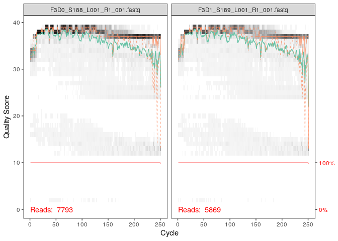

```r
#Les deux premiers reads forward :
plotQualityProfile(fnFs[1:2]) # =fonction de DADA2
```

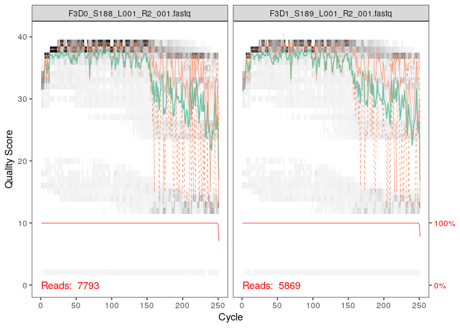

```r
#en noir = score qualité le plus fréquent à chaque position/nucléotide
#score qualité, va de 0 à 50 en général ; à 30 = 1 chance sur 10^3 que ce soit pas la bonne base, etc.
#en vert = moyenne des scores qualité
#rouge = proportion des reads qui vont au moins jusqu'à cette position

#Les deux premiers reads reverse :
plotQualityProfile(fnRs[1:2])
```

Nous définissons les noms de fichiers pour les fichiers fastq.gz filtrés :

```r
filt_path <- file.path(miseq_path,"filtered") # Placer les fichiers filtrés dans le sous-répertoire filtered/
if(!file_test("-d",filt_path)) dir.create(filt.path)
filtFs <- file.path(filt_path,paste0(sampleNames, "_F_filt.fastq.gz"))
filtRs <- file.path(filt_path,paste0(sampleNames, "_R_filt.fastq.gz"))
```

Nous combinons ces paramètres de sélection avec des paramètres de filtrage standard, le plus important étant l’application d’un maximum de 2 erreurs attendues par lecture (Edgar et Flyvbjerg 2015). Ces filtrages sont effectués conjointement sur les reads appariées, c’est-à-dire que les deux reads doivent passer le filtre pour que la paire passe.

**Filtrer les reads F et R :**

```r
out <- filterAndTrim(fnFs,filtFs,fnRs,filtRs,truncLen=c(240,160),
                     maxN=0, maxEE=c(2,2), truncQ=2, rm.phix=TRUE,
                     compress=TRUE, multithread=TRUE) #truncLen=1e valeur pour les reads Forward, 2e pour les Reverse ; quand le séquenceur ne sait pas quoi mettre, il met N, donc on veut N=0 ; truncQ=2 = on enlève toutes les bases quand le score arrive à 20 ; on ajoute l'ADN de phiX, qui sert de témoin, mais faut être sûr de bien l'enlever ensuite ; compress, car les fichiers sont compressés ; multithread= on utilise tous les processeurs de la machine.
head(out)
```

```
##                               reads.in reads.out
## F3D0_S188_L001_R1_001.fastq       7793      7113
## F3D1_S189_L001_R1_001.fastq       5869      5299
## F3D141_S207_L001_R1_001.fastq     5958      5463
## F3D142_S208_L001_R1_001.fastq     3183      2914
## F3D143_S209_L001_R1_001.fastq     3178      2941
## F3D144_S210_L001_R1_001.fastq     4827      4312
```

## Déduire les variants de séquences

Après le filtrage, le workflow bioinformatique typique des amplicons regroupe les lectures de séquençage en unités taxonomiques opérationnelles (OTU) : des groupes de lectures de séquençage qui diffèrent par moins d’un seuil de dissimilarité fixe. Ici, nous utilisons plutôt la méthode DADA2 à haute résolution pour déduire les variants de séquences d’amplicons (ASV) de manière exacte, sans imposer de seuil arbitraire, et ainsi résoudre les variantes qui diffèrent d’un seul nucléotide (Benjamin J Callahan et al. 2016).

Les données de séquence sont importées dans R à partir de fichiers fastq démultiplexés (c’est-à-dire un fastq pour chaque échantillon) et simultanément dérépliquées pour éliminer la redondance. Nous nommons les objets de la classe derep résultants par leur nom d’échantillon.

### Déréplication

La déréplication combine tous les reads de séquençage identiques en “séquences uniques” avec une “abondance” correspondante : le nombre de lectures avec cette séquence unique. La déréplication réduit considérablement le temps de calcul en éliminant les comparaisons redondantes.

```r
derepFs <- derepFastq(filtFs, verbose=TRUE)  #dérépliquer   #verbose= on lui demande d'expliquer les étapes qu'il fait
derepRs <- derepFastq(filtRs, verbose=TRUE)
# Nommer les objets de la classe Derep avec les noms des échantillons.
names(derepFs) <- sampleNames
names(derepRs) <- sampleNames
```

La méthode DADA2 s’appuie sur un modèle paramétré d’erreurs de substitution pour distinguer les erreurs de séquençage de la variation biologique réelle. Comme les taux d’erreur peuvent varier (et varient souvent) de manière substantielle entre les cycles de séquençage et les protocoles PCR, les paramètres du modèle peuvent être découverts à partir des données elles-mêmes en utilisant une forme d’apprentissage non supervisé dans laquelle l’inférence de l’échantillon est alternée avec l’estimation des paramètres jusqu’à ce que les deux soient cohérents.

L’apprentissage des paramètres est intensif en termes de calcul, car il nécessite de multiples itérations de l’algorithme d’inférence de séquence, et il est donc souvent utile d’estimer les taux d’erreur à partir d’un sous-ensemble (suffisamment grand) de données.

```r
errF <- learnErrors(filtFs, multithread=TRUE)
```

```
## 33514080 total bases in 139642 reads from 20 samples will be used for learning the error rates.
```

```r
errR <- learnErrors(filtRs, multithread=TRUE)
```

```
## 22342720 total bases in 139642 reads from 20 samples will be used for learning the error rates.
```

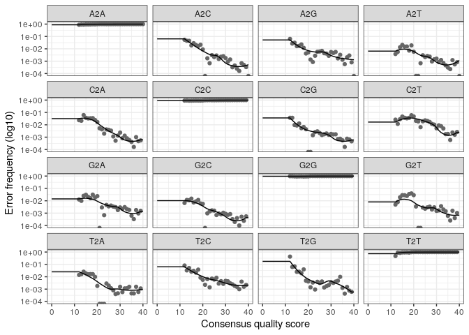

```r
plotErrors(errF) # moyenne des scores qualité en abscisse pour les différentes positions, qu'importe l'ordre ; en ordonnées, la fréquence des erreurs observées par DADA2 en log ; "A2C" = remplacement de A par C, etc.    #applique les corrections directement dans les reads
```

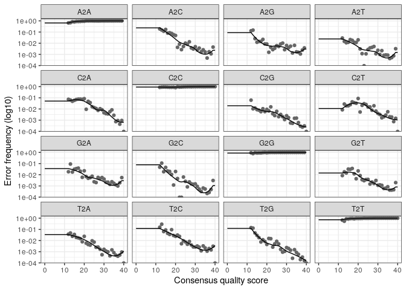

```r
plotErrors(errR)
```

Afin de vérifier que les taux d’erreur ont été raisonnablement bien estimés, nous inspectons l’ajustement entre les taux d’erreur observés (points noirs) et les taux d’erreur ajustés (lignes noires) dans la figure 1. Ces figures montrent les fréquences de chaque type de transition en fonction de la qualité.

(La seule raison de faire des OTUs = erreurs de séquençage ; donc DADA2 permet de ne plus avoir à regrouper en OTUs -> ASVs)

```r
dadaFs <- dada(derepFs, err=errF, multithread=TRUE)
```

```
## Sample 1 - 7113 reads in 1979 unique sequences.
## Sample 2 - 5299 reads in 1639 unique sequences.
## Sample 3 - 5463 reads in 1477 unique sequences.
## Sample 4 - 2914 reads in 904 unique sequences.
## Sample 5 - 2941 reads in 939 unique sequences.
## Sample 6 - 4312 reads in 1267 unique sequences.
## Sample 7 - 6741 reads in 1756 unique sequences.
## Sample 8 - 4560 reads in 1438 unique sequences.
## Sample 9 - 15637 reads in 3590 unique sequences.
## Sample 10 - 11413 reads in 2762 unique sequences.
## Sample 11 - 12017 reads in 3021 unique sequences.
## Sample 12 - 5032 reads in 1566 unique sequences.
## Sample 13 - 18075 reads in 3707 unique sequences.
## Sample 14 - 6250 reads in 1479 unique sequences.
## Sample 15 - 4052 reads in 1195 unique sequences.
## Sample 16 - 7369 reads in 1832 unique sequences.
## Sample 17 - 4765 reads in 1183 unique sequences.
## Sample 18 - 4871 reads in 1382 unique sequences.
## Sample 19 - 6504 reads in 1709 unique sequences.
## Sample 20 - 4314 reads in 897 unique sequences.
```

```r
dadaRs <- dada(derepRs, err=errR, multithread=TRUE)
```

```
## Sample 1 - 7113 reads in 1660 unique sequences.
## Sample 2 - 5299 reads in 1349 unique sequences.
## Sample 3 - 5463 reads in 1335 unique sequences.
## Sample 4 - 2914 reads in 853 unique sequences.
## Sample 5 - 2941 reads in 880 unique sequences.
## Sample 6 - 4312 reads in 1286 unique sequences.
## Sample 7 - 6741 reads in 1803 unique sequences.
## Sample 8 - 4560 reads in 1265 unique sequences.
## Sample 9 - 15637 reads in 3414 unique sequences.
## Sample 10 - 11413 reads in 2522 unique sequences.
## Sample 11 - 12017 reads in 2771 unique sequences.
## Sample 12 - 5032 reads in 1415 unique sequences.
## Sample 13 - 18075 reads in 3290 unique sequences.
## Sample 14 - 6250 reads in 1390 unique sequences.
## Sample 15 - 4052 reads in 1134 unique sequences.
## Sample 16 - 7369 reads in 1635 unique sequences.
## Sample 17 - 4765 reads in 1084 unique sequences.
## Sample 18 - 4871 reads in 1161 unique sequences.
## Sample 19 - 6504 reads in 1502 unique sequences.
## Sample 20 - 4314 reads in 732 unique sequences.
```

Inspection de l’objet renvoyé par dada :

```r
dadaFs[[1]] #premier élément d'une liste, faisant elle-même partie d'une liste
```

```
## dada-class: object describing DADA2 denoising results
## 128 sequence variants were inferred from 1979 input unique sequences.
## Key parameters: OMEGA_A = 1e-40, OMEGA_C = 1e-40, BAND_SIZE = 16
```

L’algorithme DADA2 a inféré 128 variants de séquence réels à partir des 1979 séquences uniques du premier échantillon. L’objet contient de multiples diagnostics sur la qualité de chaque variant de séquence inférée (voir help(“dada-class”) pour plus d’informations).

L’étape d’inférence de séquence DADA2 a éliminé (presque) toutes les erreurs de substitution et d’indel des données (Benjamin J Callahan et al. 2016). Nous fusionnons maintenant ensemble les séquences F et R inférées, en supprimant les séquences appariées qui ne se chevauchent pas parfaitement, comme un contrôle final contre les erreurs résiduelles.

## Construire le tableau des séquences et supprimer les chimères

La méthode DADA2 produit un tableau de séquences qui est un analogue à plus haute résolution du “tableau OTU” commun, c’est-à-dire un tableau de caractéristiques échantillons/séquences évalué par le nombre de fois que chaque séquence a été observée dans chaque échantillon.

```r
mergers <- mergePairs(dadaFs, derepFs, dadaRs, derepRs)   #on aligne les reads F et R, appliqué sur le jeu dadaFs, dérépliqué en derepFs, et idem R
```

```r
seqtabAll <- makeSequenceTable(mergers[!grepl("Mock", names(mergers))])  #nombre de fois que chaque ASV apparaît dans chaque échantillon -> table d'observations   #exclut les échantillons contenant "Mock" = communauté artificielle pour évaluer notre pipeline
table(nchar(getSequences(seqtabAll)))  #cherche les sequences dans la table qu'on vient de construire -> lecture du nombre de caractères -> table de fréquence
```

```
##
## 251 252 253 254 255
##   1  85 186   5   2
```

A noter que les chimères n’ont pas encore été supprimées. Le modèle d’erreur de l’algorithme d’inférence des séquences n’inclut pas de composante chimérique, et nous nous attendons donc à ce que ce tableau de séquences comprenne de nombreuses séquences chimériques. Nous éliminons maintenant les séquences chimériques en comparant chaque séquence inférée aux autres séquences du tableau, et en éliminant celles qui peuvent être reproduites en assemblant deux séquences plus abondantes.

```r
seqtabNoC <- removeBimeraDenovo(seqtabAll)  # chimères pendant la PCR = fragments incomplets, pour une raison x ou y l'élongation s'est arrêtée avant la fin du V4 -> le fragment s'hybride à un autre 16S amplifié car il y a des zones conservées, donc on a un mélange entre deux gènes de 16S = début d'une bactérie + fin d'une autre ; amplifié au cours des cycles restants ; mais on arrive bien à les enlever.
```

Bien que les nombres exacts varient considérablement selon les conditions expérimentales, il est typique que les chimères constituent une fraction substantielle des variants de séquence inférés, mais seulement une petite fraction de tous les reads. C’est ce que l’on observe ici : les chimères représentent environ 22 % des variants de séquence déduits, mais ces variants ne représentent qu’environ 4 % du total des reads.

## Assigner la taxonomie

```bash
cd home/rstudio
wget https://zenodo.org/record/4587955/files/silva_nr99_v138.1_train_set.fa.gz   #acquisition du jeu d'entraînement Silva, *non-exécuté*
```

```r
fastaRef <- "/home/rstudio/silva_nr99_v138.1_train_set.fa.gz"
taxTab <- assignTaxonomy(seqtabNoC, refFasta=fastaRef, multithread=TRUE)    #assigne une taxonomie à chacune de nos séquences
unname(head(taxTab))
```

```
##      [,1]       [,2]           [,3]          [,4]            [,5]
## [1,] "Bacteria" "Bacteroidota" "Bacteroidia" "Bacteroidales" "Muribaculaceae"
## [2,] "Bacteria" "Bacteroidota" "Bacteroidia" "Bacteroidales" "Muribaculaceae"
## [3,] "Bacteria" "Bacteroidota" "Bacteroidia" "Bacteroidales" "Muribaculaceae"
## [4,] "Bacteria" "Bacteroidota" "Bacteroidia" "Bacteroidales" "Muribaculaceae"
## [5,] "Bacteria" "Bacteroidota" "Bacteroidia" "Bacteroidales" "Bacteroidaceae"
## [6,] "Bacteria" "Bacteroidota" "Bacteroidia" "Bacteroidales" "Muribaculaceae"
##      [,6]
## [1,] NA
## [2,] NA
## [3,] NA
## [4,] NA
## [5,] "Bacteroides"
## [6,] NA
```

## Construire l’arbre phylogénétique

La parenté phylogénétique est couramment utilisée pour informer les analyses en aval, en particulier le calcul des distances phylogéniques entre les communautés microbiennes. La méthode d’inférence de séquence DADA2 est sans référence, nous devons donc construire de novo l’arbre phylogénétique reliant les variantes de séquence inférées. Nous commençons par effectuer un alignement multiple à l’aide du package R DECIPHER (Wright 2015).

```r
seqs <- getSequences(seqtabNoC)   #prend le nom de chaque colonne (=les séquences), donc = liste de séquences
names(seqs) <- seqs #Cela se propage aux étiquettes des branches de l'arbre
alignment <- AlignSeqs(DNAStringSet(seqs), anchor=NA, verbose=FALSE)
```

Le package R phangorn est ensuite utilisé pour construire un arbre phylogénétique. Ici, nous construisons d’abord un arbre neighbor-joining, puis nous ajustons un arbre de maximum de vraisemblance GTR+G+I (Generalized time-reversible with Gamma rate variation) en utilisant l’arbre neighbor-joining comme point de départ.

[figure not shown]

```r
phangAlign <- phyDat(as(alignment,"matrix"),type="DNA")
dm <- dist.ml(phangAlign)
treeNJ <- NJ(dm)  # Note, tip order != sequence order
fit = pml(treeNJ, data=phangAlign)
fitGTR <- update(fit, k=4, inv=0.2)
fitGTR <- optim.pml(fitGTR, model="GTR", optInv=TRUE, optGamma=TRUE,
                    rearrangement="stochastic", control=pml.control(trace=0))
plot(fitGTR)
```

```r
detach("package:phangorn", unload=TRUE)
```

## Combiner les données dans un objet phyloseq

Le package phyloseq organise et synthétise les différents types de données d’une expérience typique de séquençage d’amplicons en un seul objet de données qui peut être facilement manipulé. La dernière information nécessaire est l’échantillon de données contenu dans un fichier .csv. Celui-ci peut être téléchargé sur github :

```r
samdf <- read.csv("https://raw.githubusercontent.com/spholmes/F1000_workflow/master/data/MIMARKS_Data_combined.csv",header=TRUE)  #métadonnées associées à nos souris
samdf$SampleID <- paste0(gsub("00", "", samdf$host_subject_id), "D", samdf$age-21)    #corriger des erreurs
samdf <- samdf[!duplicated(samdf$SampleID),] # Supprimer les entrées en double pour les lectures inversées      (reçoit les infos de sampleID)
rownames(seqtabAll) <- gsub("124", "125", rownames(seqtabAll)) # Corriger l'écart
all(rownames(seqtabAll) %in% samdf$SampleID) # TRUE
```

```
## [1] TRUE
```

```r
rownames(samdf) <- samdf$SampleID
keep.cols <- c("collection_date", "biome", "target_gene", "target_subfragment",
"host_common_name", "host_subject_id", "age", "sex", "body_product", "tot_mass",
"diet", "family_relationship", "genotype", "SampleID")    #ne garder que ces colonnes
samdf <- samdf[rownames(seqtabAll), keep.cols]   #reçoit les lignes de seqtaball et qui sont dans le vecteur keepcols
```

L’ensemble des données de cette étude - le tableau échantillons/séquences, les métadonnées de l’échantillon, les taxonomies des séquences et l’arbre phylogénétique - peut maintenant être combiné en un seul objet.

```r
ps <- phyloseq(otu_table(seqtabNoC, taxa_are_rows=FALSE),   #ps reçoit la commande phyloseq, appliquée à seqtabnoc= table d'observations, pas de lignes qui définisent la taxonomie, et on spécifie que c'est une otu_table
               sample_data(samdf),       #sur table de métadonnées
               tax_table(taxTab),phy_tree(fitGTR$tree))      #sur taxtab ; phytree c'est l'arbre phylogénétique, et cherche l'arbre dans fitGR
ps <- prune_samples(sample_names(ps) != "Mock", ps) # Retirer l'échantillon fictif (mock)   #prune= enlever, donc on garde les échantillons qui ne contiennent pas Mock
ps
```

```
## phyloseq-class experiment-level object
## otu_table()   OTU Table:         [ 218 taxa and 19 samples ]
## sample_data() Sample Data:       [ 19 samples by 14 sample variables ]
## tax_table()   Taxonomy Table:    [ 218 taxa by 6 taxonomic ranks ]
## phy_tree()    Phylogenetic Tree: [ 218 tips and 216 internal nodes ]
```

# Utilisation de phyloseq

phyloseq(McMurdie and Holmes 2013) est un package R permettant d’importer, de stocker, d’analyser et d’afficher graphiquement des données complexes de séquençage phylogénétique qui ont déjà été regroupées en unités taxonomiques opérationnelles (OTU) ou, de manière plus appropriée, débruitées. Il est particulièrement utile lorsqu’il existe également des données d’échantillon associées, une phylogénie et/ou une affectation taxonomique de chaque taxon. phyloseq exploite et s’appuie sur de nombreux outils disponibles dans R pour l’écologie et l’analyse phylogénétique (ape, vegan, ade4), tout en utilisant des systèmes graphiques avancés/flexibles (ggplot2) pour produire facilement des graphiques de qualité de publication de données phylogénétiques complexes. Le package phyloseq utilise un système spécialisé de classes de données S4 pour stocker toutes les données de séquençage phylogénétique connexes sous la forme d’un objet de niveau expérimental unique, autoconsistant et autodescriptif, ce qui facilite le partage des données et la reproduction des analyses. En général, phyloseq cherche à faciliter l’utilisation de R pour une analyse efficace, interactive et reproductible des données de comptage d’amplicons conjointement avec des covariables importantes de l’échantillon.

## Chargement de données

De nombreux cas d’utilisation entraînent le besoin d’importer et de combiner différentes données dans un objet de classe phyloseq, ceci peut être fait en utilisant la fonction import_biom pour lire les fichiers récents au format QIIME, les fichiers plus anciens peuvent toujours être importés avec import_qiime. Des détails plus complets peuvent être trouvés sur la page FAQ de phyloseq.

Dans la section précédente, les résultats du traitement des séquences de dada2 ont été organisés dans un objet phyloseq. Nous avons en fait exécuté dada2 sur un ensemble plus important d’échantillons provenant de la même source de données. Cet objet a également été sauvegardé au format RDS sérialisé natif de R. Nous le rechargerons ici pour être plus complet. Nous allons le recharger ici par souci d’exhaustivité comme l’objet initial ps. Si vous n’avez pas téléchargé l’ensemble du dépôt, vous pouvez accéder au fichier ps via github :

```r
#remplace le ps établi avant, car erreur à la fin !
ps_connect <-url("https://raw.githubusercontent.com/spholmes/F1000_workflow/master/data/ps.rds")
ps = readRDS(ps_connect)
ps
```

```
## phyloseq-class experiment-level object
## otu_table()   OTU Table:         [ 389 taxa and 360 samples ]
## sample_data() Sample Data:       [ 360 samples by 14 sample variables ]
## tax_table()   Taxonomy Table:    [ 389 taxa by 6 taxonomic ranks ]
## phy_tree()    Phylogenetic Tree: [ 389 tips and 387 internal nodes ]
```

## Shiny-phyloseq

Il peut être bénéfique de commencer le processus d’exploration des données de manière interactive, cela permet souvent de gagner du temps dans la détection des valeurs aberrantes et des caractéristiques spécifiques des données. Shiny-phyloseq (McMurdie et Holmes 2015) est une application web interactive qui fournit une interface utilisateur graphique au paquet phyloseq. L’objet qui vient d’être chargé dans la session R dans ce flux de travail convient à l’exploration graphique avec Shiny-phyloseq.

## Filtrage

phyloseq fournit des outils utiles pour le filtrage, le sous-ensemble et l’agglomération des taxons - une tâche qui est souvent appropriée ou même nécessaire pour une analyse efficace des données de comptage du microbiome. Dans cette sous-section, nous explorons graphiquement la prévalence des taxa dans l’ensemble de données de l’exemple, et nous démontrons comment cela peut être utilisé comme critère de filtrage. L’une des raisons de filtrer de cette manière est d’éviter de passer beaucoup de temps à analyser des taxons qui n’ont été vus que rarement parmi les échantillons. Cette méthode s’avère également utile pour filtrer le bruit (les taxons qui ne sont en fait que des artefacts du processus de collecte des données), une étape qui devrait probablement être considérée comme essentielle pour les ensembles de données construits à l’aide de méthodes heuristiques de regroupement des OTU, qui sont notoirement enclines à générer des taxons parasites.

### Filtrage taxonomique

Dans de nombreux contextes biologiques, l’ensemble des organismes de tous les échantillons est bien représenté dans la base de données taxonomique de référence disponible. Si (et seulement si) c’est le cas, il est raisonnable ou même conseillé de filtrer les caractéristiques taxonomiques pour lesquelles une taxonomie de haut rang n’a pu être attribuée. Dans ce cas, les caractéristiques ambiguës sont presque toujours des artefacts de séquence qui n’existent pas dans la nature. Il devrait être évident qu’un tel filtre n’est pas approprié pour les échantillons provenant de spécimens mal caractérisés ou nouveaux, du moins jusqu’à ce que la possibilité de nouveauté taxonomique puisse être rejetée de manière satisfaisante. Phylum est un rang taxonomique utile à utiliser à cette fin, mais d’autres peuvent fonctionner efficacement pour vos données.

Pour commencer, créer un tableau des comptes de lecture pour chaque phylum présent dans l’ensemble de données.

```r
# Afficher les rangs disponibles dans l'ensemble de données
rank_names(ps)
```

```
## [1] "Kingdom" "Phylum"  "Class"   "Order"   "Family"  "Genus"
```

```r
# Créer un tableau, nombre de caractéristiques pour chaque phylum
table(tax_table(ps)[, "Phylum"], exclude = NULL)  #on exclut quand le champ Phylum est nul
```

```
##
##              Actinobacteria               Bacteroidetes
##                          13                          23
## Candidatus_Saccharibacteria   Cyanobacteria/Chloroplast
##                           1                           4
##         Deinococcus-Thermus                  Firmicutes
##                           1                         327
##                Fusobacteria              Proteobacteria
##                           1                          11
##                 Tenericutes             Verrucomicrobia
##                           1                           1
##                        <NA>
##                           6
```

Ceci montre quelques phyla pour lesquels une seule entité a été observée. Ceux-ci peuvent valoir la peine d’être filtrés, et nous allons vérifier cela ensuite. D’abord, remarquons que dans ce cas, six séquences ont été annotées avec un phylum de NA. Celles-ci sont probablement des artefacts dans un ensemble de données comme celui-ci, et doivent être supprimées.

Ce qui suit assure que les ASV avec une annotation de phylum ambiguë sont également supprimées. Notez la flexibilité dans la définition des chaînes qui devraient être considérées comme une annotation ambiguë.

```r
ps <- subset_taxa(ps, !is.na(Phylum) & !Phylum %in% c("", "uncharacterized")) #on enlève aussi quand phylum est marqué NA
```

Une étape suivante utile consiste à explorer la prévalence des ASV dans l’ensemble de données, que nous définirons ici comme le nombre d’échantillons dans lesquels un taxon apparaît au moins une fois.

```r
# Calculer la prévalence de chaque caractéristique, la stocker dans une dataframe.                #(Pas nécessaire.)
prevdf = apply(X = otu_table(ps),
               MARGIN = ifelse(taxa_are_rows(ps), yes = 1, no = 2),
               FUN = function(x){sum(x > 0)})
# Ajouter la taxonomie et le nombre total de reads à cette dataframe
prevdf = data.frame(Prevalence = prevdf,
                    TotalAbundance = taxa_sums(ps),
                    tax_table(ps))
```

Existe-t-il des embranchements composés principalement de caractéristiques à faible prévalence ? Calculer les prévalences totales et moyennes des caractéristiques dans chaque phylum.

```r
plyr::ddply(prevdf, "Phylum", function(df1){cbind(mean(df1$Prevalence),sum(df1$Prevalence))})
```

```
##                         Phylum         1     2
## 1               Actinobacteria 120.15385  1562
## 2                Bacteroidetes 265.52174  6107
## 3  Candidatus_Saccharibacteria 280.00000   280
## 4    Cyanobacteria/Chloroplast  64.25000   257
## 5          Deinococcus-Thermus  52.00000    52
## 6                   Firmicutes 179.24771 58614
## 7                 Fusobacteria   2.00000     2
## 8               Proteobacteria  59.09091   650
## 9                  Tenericutes 234.00000   234
## 10             Verrucomicrobia 104.00000   104
```

```r
# Définir les phyla à filtrer
filterPhyla = c("Fusobacteria", "Deinococcus-Thermus")
# Filtrer les entrées dont le phylum n'est pas identifié.
ps1 = subset_taxa(ps, !Phylum %in% filterPhyla)
ps1
```

```
## phyloseq-class experiment-level object
## otu_table()   OTU Table:         [ 381 taxa and 360 samples ]
## sample_data() Sample Data:       [ 360 samples by 14 sample variables ]
## tax_table()   Taxonomy Table:    [ 381 taxa by 6 taxonomic ranks ]
## phy_tree()    Phylogenetic Tree: [ 381 tips and 379 internal nodes ]
```

### Filtrage de la prévalence

Les étapes de filtrage précédentes sont considérées comme supervisées, car elles reposent sur des informations préalables externes à cette expérience (une base de données de référence taxonomique). L’étape de filtrage suivante est complètement non supervisée, car elle repose uniquement sur les données de cette expérience et sur un paramètre que nous choisirons après avoir exploré les données. Ainsi, cette étape de filtrage peut être appliquée même dans des contextes où l’annotation taxonomique est indisponible ou peu fiable.

D’abord, explorer la relation entre la prévalence et le nombre total de reads pour chaque caractéristique. Parfois, cela révèle des valeurs aberrantes qui devraient probablement être supprimées, et donne également un aperçu des plages de chaque caractéristique qui pourraient être utiles. Cet aspect dépend beaucoup du plan expérimental et des objectifs de l’inférence en aval, il faut donc les garder à l’esprit. Il se peut même que différents types d’inférences en aval nécessitent des choix différents. Il n’y a aucune raison de s’attendre à l’avance à ce qu’un seul flux de travail de filtrage soit approprié pour toutes les analyses.

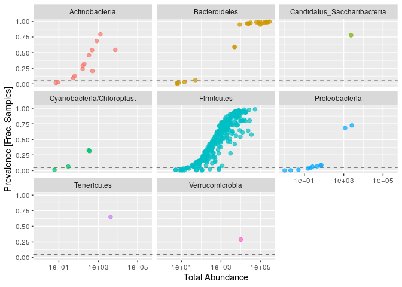

```r
# Sous-ensemble des phyla restants
prevdf1 = subset(prevdf, Phylum %in% get_taxa_unique(ps1, "Phylum"))
ggplot(prevdf1, aes(TotalAbundance, Prevalence / nsamples(ps),color=Phylum)) +
  # Inclure une estimation pour le paramètre
  geom_hline(yintercept = 0.05, alpha = 0.5, linetype = 2) +  geom_point(size = 2, alpha = 0.7) +
  scale_x_log10() +  xlab("Total Abundance") + ylab("Prevalence [Frac. Samples]") +
  facet_wrap(~Phylum) + theme(legend.position="none")
```

Chaque point de la figure 2 représente un taxon différent. L’exploration des données de cette manière est souvent utile pour sélectionner des paramètres de filtrage, comme le critère de prévalence minimale que nous utiliserons pour filtrer les données ci-dessus.

Parfois, une séparation naturelle dans l’ensemble de données se révèle, ou du moins, un choix conservateur qui se trouve dans une région stable pour laquelle de petites modifications du choix auraient un effet mineur ou nul sur l’interprétation biologique (stabilité). Ici, aucune séparation naturelle n’est immédiatement évidente, mais il semble que nous pourrions raisonnablement définir un seuil de prévalence dans une fourchette de zéro à dix pour cent environ. Il faut veiller à ce que ce choix n’introduise pas de biais dans une analyse en aval de l’association de l’abondance différentielle.

L’exemple suivant utilise 5 % de tous les échantillons comme seuil de prévalence.

```r
# Définir le seuil de prévalence comme 5% du total des échantillons
prevalenceThreshold = 0.05 * nsamples(ps)
prevalenceThreshold
```

```
## [1] 18
```

```r
# Exécuter le filtre de prévalence, en utilisant la fonction `prune_taxa()`
keepTaxa = rownames(prevdf1)[(prevdf1$Prevalence >= prevalenceThreshold)]
ps2 = prune_taxa(keepTaxa, ps)
```

## Agglomérer les taxa

Lorsque l’on sait qu’il y a beaucoup de redondance fonctionnelle entre espèces ou sous-espèces dans une communauté microbienne, il peut être utile d’agglomérer les caractéristiques des données correspondant à des taxa étroitement liés. L’idéal serait de connaître parfaitement les redondances fonctionnelles à l’avance, auquel cas on agglomérerait les taxa en utilisant ces relations définies et la fonction dans phyloseq. Ce type de données fonctionnelles précises n’est généralement pas disponible, et différentes associations de microorganismes auront des ensembles différents de fonctions qui se chevauchent, ce qui complique la définition de critères de regroupement appropriés.

Bien que ce ne soit pas nécessairement le critère le plus utile ou le plus précis du point de vue fonctionnel pour regrouper les caractéristiques microbiennes (il est parfois loin d’être précis), l’agglomération taxonomique a l’avantage d’être beaucoup plus facile à définir à l’avance. En effet, les taxonomies sont généralement définies à l’aide d’une structure graphique arborescente relativement simple, comportant un nombre fixe de nœuds internes, appelés “rangs”. Cette structure est suffisamment simple pour que le package phyloseq représente les taxonomies sous forme de tableau d’étiquettes de taxonomie. L’agglomération taxonomique regroupe toutes les “feuilles” de la hiérarchie qui descendent du rang d’agglomération prescrit par l’utilisateur, ceci est parfois appelé “glomming”.

L’exemple de code suivant montre comment on pourrait combiner toutes les caractéristiques qui descendent du même genre.

```r
# Combien de genres seraient présents après le filtrage ?
length(get_taxa_unique(ps2, taxonomic.rank = "Genus"))
```

```
## [1] 49
```

```r
ps3 = tax_glom(ps2, "Genus", NArm = TRUE)
```

Si la taxonomie n’est pas disponible ou n’est pas fiable, l’agglomération par arbre est une alternative “sans taxonomie” pour combiner des caractéristiques de données correspondant à des taxons étroitement liés. Dans ce cas, plutôt que le rang taxonomique, l’utilisateur spécifie une hauteur d’arbre correspondant à la distance phylogénétique entre les caractéristiques qui devrait définir leur regroupement. Cette méthode est très similaire au “clustering d’OTU”, sauf que dans de nombreux algorithmes de clustering d’OTU, la distance de séquence utilisée n’a pas la même (ou aucune) définition évolutive.

```r
h1 = 0.4
ps4 = tip_glom(ps2, h = h1)
```

La fonction plot_tree() de phyloseq compare ici les données originales non filtrées, l’arbre après agglomération taxonomique, et l’arbre après agglomération phylogénétique. Ils sont stockés comme des objets de tracé séparés, puis rendus ensemble dans un graphique combiné en utilisant gridExtra::grid.arrange.

```r
multiPlotTitleTextSize = 15
p2tree = plot_tree(ps2, method = "treeonly",
                   ladderize = "left",
                   title = "Before Agglomeration") +
  theme(plot.title = element_text(size = multiPlotTitleTextSize))
p3tree = plot_tree(ps3, method = "treeonly",
                   ladderize = "left", title = "By Genus") +
  theme(plot.title = element_text(size = multiPlotTitleTextSize))
p4tree = plot_tree(ps4, method = "treeonly",
                   ladderize = "left", title = "By Height") +
  theme(plot.title = element_text(size = multiPlotTitleTextSize))
```

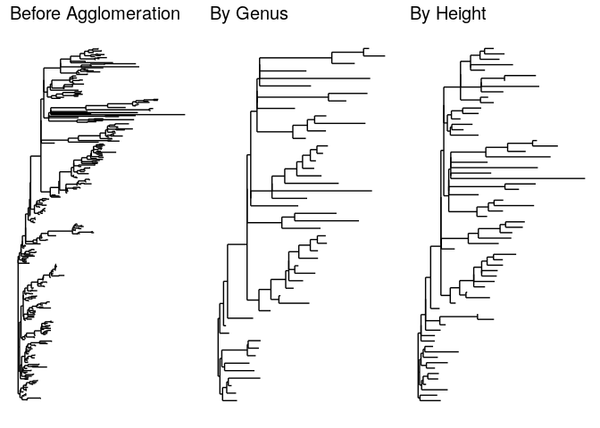

```r
#Regrouper les plots ensemble
grid.arrange(nrow = 1, p2tree, p3tree, p4tree)
```

La figure 3 montre l’arbre original à gauche, l’agglomération taxonomique au rang de Genus au milieu et l’agglomération phylogénétique à une distance fixe de 0,4 à droite.

## Transformation de la valeur de l’abondance

Il est généralement nécessaire de transformer les données de comptage du microbiome pour tenir compte des différences de taille de la bibliothèque, de la variance, de l’échelle, etc. Le paquet phyloseq fournit une interface flexible pour définir de nouvelles fonctions pour accomplir ces transformations des valeurs d’abondance via la fonction transform_sample_counts(). Le premier argument de cette fonction est l’objet phyloseq que vous voulez transformer, et le deuxième argument est une fonction R qui définit la transformation. La fonction R est appliquée par échantillon, en s’attendant à ce que le premier argument non nommé soit un vecteur de comptes de taxons dans le même ordre que l’objet phyloseq. Des arguments supplémentaires sont transmis à la fonction spécifiée dans le second argument, fournissant un moyen explicite d’inclure des valeurs pré-calculées, des paramètres/seuils précédemment définis, ou tout autre objet qui pourrait être approprié pour calculer les valeurs transformées d’intérêt.

Cet exemple commence par définir une fonction de tracé personnalisée, plot_abundance(), qui utilise la fonction de phyloseq pour définir un graphique d’abondance relative. Nous allons l’utiliser pour comparer plus facilement les différences d’échelle et de distribution des valeurs d’abondance dans notre objet phyloseq avant et après transformation.

```r
plot_abundance = function(physeq,title = "",
                          Facet = "Order", Color = "Phylum"){
  # Sous-ensemble arbitraire, basé sur le phylum, pour le traçage.
  p1f = subset_taxa(physeq, Phylum %in% c("Firmicutes"))
  mphyseq = psmelt(p1f)
  mphyseq <- subset(mphyseq, Abundance > 0)
  ggplot(data = mphyseq, mapping = aes_string(x = "sex",y = "Abundance",
                              color = Color, fill = Color)) +
    geom_violin(fill = NA) +
    geom_point(size = 1, alpha = 0.3,
               position = position_jitter(width = 0.3)) +
    facet_wrap(facets = Facet) + scale_y_log10()+
    theme(legend.position="none")
}
```

Dans ce cas, la transformation convertit les comptages de chaque échantillon en leurs fréquences, souvent appelées proportions ou abondances relatives. Cette fonction est si simple qu’il est plus facile de la définir dans l’appel à la fonction transform_sample_counts().

```r
# Transformer en abondance relative. Sauvegarde en tant que nouvel objet.
ps3ra = transform_sample_counts(ps3, function(x){x / sum(x)})
```

Nous traçons maintenant les valeurs d’abondance avant et après la transformation.

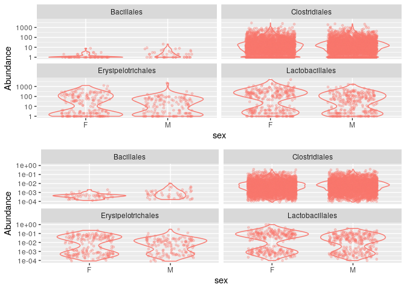

```r
plotBefore = plot_abundance(ps3,"")
plotAfter = plot_abundance(ps3ra,"")
# Combiner chaque graphe en un seul graphique.
grid.arrange(nrow = 2,  plotBefore, plotAfter)
```

La figure 4 montre la comparaison des abondances originales (panneau supérieur) et des abondances relatives (panneau inférieur).

## Sous-ensemble par taxonomie

Remarque : sur le graphique précédent que *Lactobacillales* semble être un ordre taxonomique avec un profil d’abondance bimodal dans les données. Nous pouvons vérifier l’explication taxonomique de ce modèle en traçant uniquement ce sous-ensemble taxonomique des données. Pour cela, nous faisons un sous-ensemble avec la fonction, puis nous spécifions un rang taxonomique plus précis à l’argument de la fonction que nous avons défini ci-dessus.

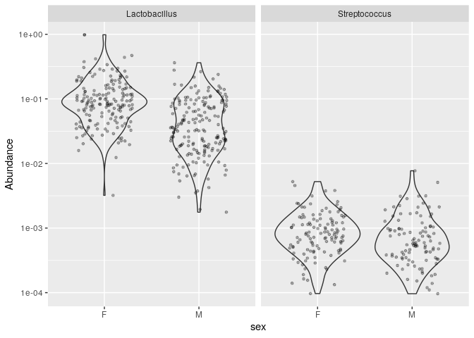

```r
psOrd = subset_taxa(ps3ra, Order == "Lactobacillales")
plot_abundance(psOrd, Facet = "Genus", Color = NULL)
```

La figure 5 montre les abondances relatives de l’ordre taxonomique des Lactobacillales, regroupées par sexe de l’hôte et par genre. Ici, il est clair que la distribution bimodale apparente des Lactobacillales sur le graphique précédent était le résultat d’un mélange de deux genres différents, avec l’abondance relative typique de *Lactobacillus* beaucoup plus grande que celle de *Streptococcus*.

À ce stade du workflow, après avoir converti les reads bruts en abondances d’espèces interprétables, et après avoir filtré et transformé ces abondances pour concentrer l’attention sur des quantités scientifiquement significatives, nous sommes en mesure d’envisager une analyse statistique plus attentive. R est un environnement idéal pour effectuer ces analyses, car il dispose d’une communauté active de développeurs de packages qui créent des interfaces simples pour des techniques sophistiquées. Comme de nombreuses méthodes sont disponibles, il n’est pas nécessaire de s’engager a priori dans une stratégie d’analyse rigide. De plus, la possibilité d’appeler facilement des packages sans réimplémenter les méthodes permet aux chercheurs d’itérer rapidement à travers des idées d’analyse alternatives. L’avantage d’exécuter ce workflow complet dans R est que cette transition de la bioinformatique aux statistiques se fait sans effort.

Commençons par installer quelques packages qui sont disponibles pour ces analyses complémentaires :

```r
.cran_packages <- c( "shiny","miniUI", "caret", "pls", "e1071", "ggplot2", "randomForest", "dplyr", "ggrepel", "nlme", "devtools",
                  "reshape2", "PMA", "structSSI", "ade4",
                  "ggnetwork", "intergraph", "scales")
.github_packages <- c("jfukuyama/phyloseqGraphTest")
.bioc_packages <- c("genefilter", "impute")
# Installer les packages CRAN (s'ils ne sont pas déjà installés)
.inst <- .cran_packages %in% installed.packages()
if (any(!.inst)){
  install.packages(.cran_packages[!.inst],repos = "http://cran.rstudio.com/")
}
.inst <- .github_packages %in% installed.packages()
if (any(!.inst)){
  devtools::install_github(.github_packages[!.inst])
}

.inst <- .bioc_packages %in% installed.packages()
if(any(!.inst)){BiocManager::install(.bioc_packages[!.inst])
}
```

Nous étayons ces affirmations en illustrant plusieurs analyses sur les données de souris préparées ci-dessus. Nous expérimentons plusieurs variantes de l’ordination exploratoire avant de passer à des tests et à une modélisation plus formels, en expliquant les contextes dans lesquels les différents points de vue sont les plus appropriés. Enfin, nous fournissons des exemples d’analyses de données multitables, en utilisant une étude dans laquelle les mesures métabolomiques et d’abondance microbienne ont été collectées sur les mêmes échantillons, afin de démontrer que le workflow général présenté ici peut être adapté au multitable.

### Preprocessing

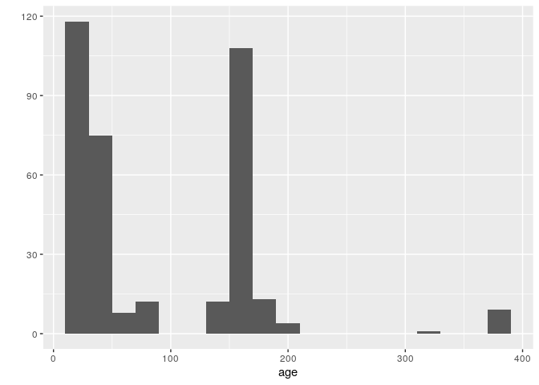

```r
qplot(sample_data(ps)$age, geom = "histogram",binwidth=20) + xlab("age")
```

La figure 6 montre que la covariable âge appartient à trois groupes distincts.

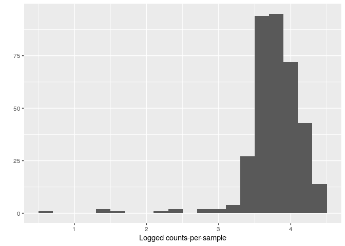

```r
qplot(log10(rowSums(otu_table(ps))),binwidth=0.2) +
  xlab("Logged counts-per-sample")
```

Ces graphiques préliminaires suggèrent certaines étapes de prétraitement. L’histogramme de la Figure 6 motive la création d’une nouvelle variable catégorielle, classant l’âge dans l’un des trois pics.

L’histogramme de la Figure 7 suggère qu’une transformation log(1+x) pourrait être suffisante pour normaliser les données d’abondance pour les analyses exploratoires.

En fait, cette transformation n’est pas suffisante pour les tests et lorsque nous effectuons des abondances différentielles, nous recommandons les transformations de stabilisation de la variance disponibles dans DESeq2 via la fonction phyloseq_to_deseq2, voir le tutoriel phyloseq_to_deseq2 ici.

Comme première étape, nous examinons l’analyse des coordonnées principales (PCoA) avec la dissimilarité de Bray-Curtis ou la distance Unifrac pondérée.

```r
sample_data(ps)$age_binned <- cut(sample_data(ps)$age,
                          breaks = c(0, 100, 200, 400))
levels(sample_data(ps)$age_binned) <- list(Young100="(0,100]", Mid100to200="(100,200]", Old200="(200,400]")
sample_data(ps)$family_relationship=gsub(" ","",sample_data(ps)$family_relationship)
pslog <- transform_sample_counts(ps, function(x) log(1 + x))
out.wuf.log <- ordinate(pslog, method = "MDS", distance = "wunifrac")
```

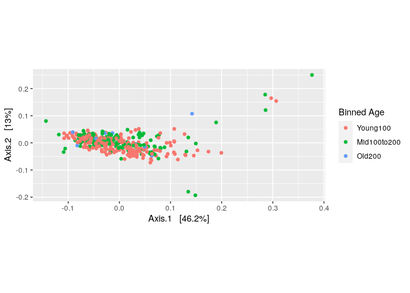

```r
evals <- out.wuf.log$values$Eigenvalues
plot_ordination(pslog, out.wuf.log, color = "age_binned") +
  labs(col = "Binned Age") +
  coord_fixed(sqrt(evals[2] / evals[1]))
```

La figure 8, qui montre l’ordination des données d’abondance enregistrées, révèle quelques valeurs aberrantes.

Il s’agit des échantillons des femelles 5 et 6 au jour 165 et des échantillons des mâles 3, 4, 5 et 6 au jour 175. Nous allons les supprimer, puisque nous sommes principalement intéressés par les relations entre les points non aberrants.  
Avant de continuer, nous devons vérifier les deux points aberrants des femelles - ils ont été pris en charge par le même OTU/ASV, qui a une abondance relative de plus de 90% dans chacun d’eux. C’est la seule fois dans l’ensemble des données que cette ASV a une abondance relative aussi élevée - le reste du temps, elle est inférieure à 20%. En particulier, sa diversité est de loin la plus faible de tous les échantillons.

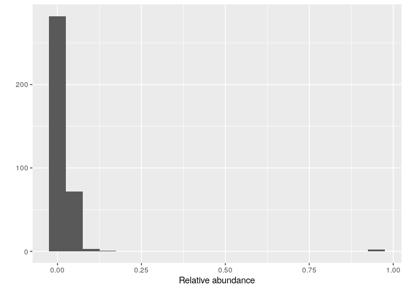

```r
rel_abund <- t(apply(otu_table(ps), 1, function(x) x / sum(x)))
qplot(rel_abund[, 12], geom = "histogram",binwidth=0.05) +
  xlab("Relative abundance")
```

# Projections d’ordinations différentes

Comme nous l’avons vu, une première étape importante dans l’analyse des données du microbiome est de faire une analyse exploratoire non supervisée. Ceci est simple à faire dans phyloseq, qui fournit de nombreuses distances et méthodes d’ordination.

Après avoir documenté les valeurs aberrantes, nous allons calculer des ordinations avec ces valeurs aberrantes enlevées et étudier plus attentivement le résultat.

```r
outliers <- c("F5D165", "F6D165", "M3D175", "M4D175", "M5D175", "M6D175")
ps <- prune_samples(!(sample_names(ps) %in% outliers), ps)
```

Nous allons également supprimer les échantillons ayant moins de 1000 reads :

```r
which(!rowSums(otu_table(ps)) > 1000)
```

```
## F5D145 M1D149   M1D9 M2D125  M2D19 M3D148 M3D149   M3D3   M3D5   M3D8
##     69    185    200    204    218    243    244    252    256    260
```

```r
ps <- prune_samples(rowSums(otu_table(ps)) > 1000, ps)
pslog <- transform_sample_counts(ps, function(x) log(1 + x))
```

Nous allons d’abord effectuer une PCoA en utilisant la dissimilarité de Bray-Curtis.

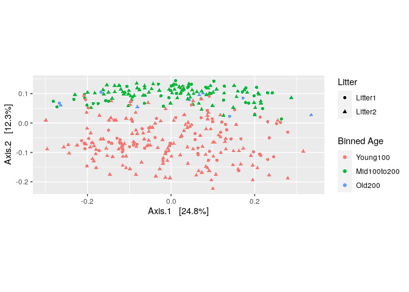

```r
out.pcoa.log <- ordinate(pslog,  method = "MDS", distance = "bray")
evals <- out.pcoa.log$values[,1]
plot_ordination(pslog, out.pcoa.log, color = "age_binned",
                  shape = "family_relationship") +
  labs(col = "Binned Age", shape = "Litter")+
  coord_fixed(sqrt(evals[2] / evals[1]))
```

Nous constatons qu’il existe un effet d’âge assez important qui est cohérent entre toutes les souris, mâles et femelles, et provenant de différentes portées.

Ensuite, nous examinons l’analyse des coordonnées principales doubles (DPCoA) (Pavoine, Dufour et Chessel 2004 ; Purdom 2010 ; Fukuyama et al. 2012), qui est une méthode d’ordination phylogénétique et qui fournit une représentation biplot des échantillons et des catégories taxonomiques. Nous voyons à nouveau que le deuxième axe correspond aux jeunes souris par rapport aux vieilles souris, et le biplot suggère une interprétation du deuxième axe : les échantillons qui ont des scores plus élevés sur le deuxième axe ont plus de taxa de *Bacteroidetes* et un sous-ensemble de *Firmicutes*.

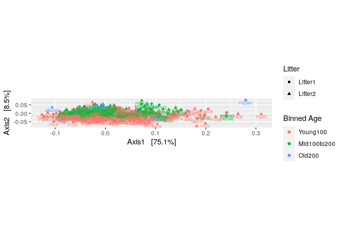

```r
out.dpcoa.log <- ordinate(pslog, method = "DPCoA")
evals <- out.dpcoa.log$eig
plot_ordination(pslog, out.dpcoa.log, color = "age_binned", label= "SampleID",
                  shape = "family_relationship") +
  labs(col = "Binned Age", shape = "Litter")+
  coord_fixed(sqrt(evals[2] / evals[1]))
```

Dans la figure 11, le premier axe explique 75 % de la variabilité, soit environ 9 fois celle du deuxième axe ; cela se traduit par la forme allongée du graphique d’ordination.

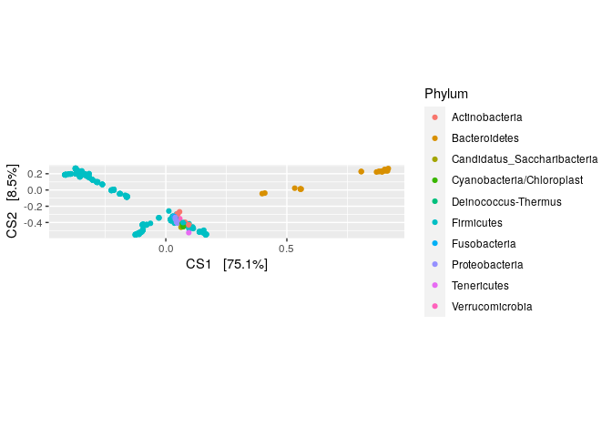

```r
plot_ordination(pslog, out.dpcoa.log, type = "species", color = "Phylum") +
  coord_fixed(sqrt(evals[2] / evals[1]))
```

Enfin, nous pouvons examiner les résultats de la PCoA avec Unifrac pondéré. Comme précédemment, nous constatons que le deuxième axe est associé à un effet d’âge, ce qui est assez similaire au DPCoA. Cela n’est pas surprenant, car les deux méthodes d’ordination phylogénétique prennent en compte l’abondance. Cependant, lorsque nous comparons les biplots, nous constatons que la DPCoA donne une interprétation beaucoup plus propre du deuxième axe, par rapport à Unifrac pondéré.

```r
out.wuf.log <- ordinate(pslog, method = "PCoA", distance ="wunifrac")
```

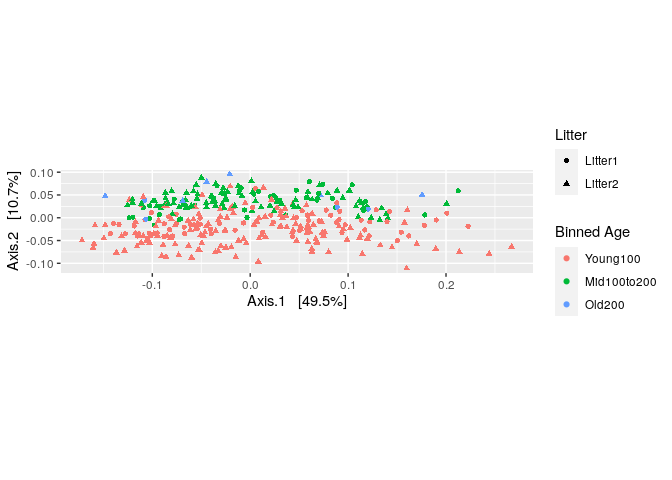

```r
evals <- out.wuf.log$values$Eigenvalues
plot_ordination(pslog, out.wuf.log, color = "age_binned",
                  shape = "family_relationship") +
  coord_fixed(sqrt(evals[2] / evals[1])) +
  labs(col = "Binned Age", shape = "Litter")
```

## Pourquoi les courbes d’ordination sont-elles si éloignées du carré ?

### Rapport d’aspect des diagrammes d’ordination

Dans les diagrammes d’ordination de la Figure 8 à la Figure 14, les cartes ne sont pas présentées sous forme de représentations carrées, comme c’est souvent le cas dans les diagrammes PCoA et PCA standard de la littérature.

La raison en est que, comme nous essayons de représenter les distances entre les échantillons aussi fidèlement que possible, nous devons tenir compte du fait que la deuxième valeur propre est toujours plus petite que la première, parfois considérablement, et nous normalisons donc les rapports de la norme de l’axe aux rapports des valeurs propres pertinentes. Cela permet de garantir que la variabilité représentée dans les graphiques l’est de manière fidèle.

### PCA on ranks

Les données sur l’abondance microbienne sont souvent fortement inclinées, et il est parfois difficile d’identifier une transformation qui ramène les données à la normalité. Dans ces cas, il peut être plus sûr d’ignorer complètement les abondances brutes et de travailler plutôt avec des rangs. Nous démontrons cette idée en utilisant une version des données transformées en rangs pour effectuer une ACP. Tout d’abord, nous créons une nouvelle matrice, représentant les abondances par leurs rangs, où le micro-organisme le plus petit dans un échantillon est affecté au rang 1, le deuxième plus petit au rang 2, etc.

```r
abund <- otu_table(pslog)
abund_ranks <- t(apply(abund, 1, rank))
```

L’utilisation naïve de ces rangs pourrait rendre comparables les différences entre les ensembles de micro-organismes à faible et à forte abondance. Dans le cas où de nombreuses bactéries sont absentes ou présentes à l’état de traces, une différence de rang artificiellement importante pourrait se produire (Holmes et al. 2011) pour les taxa peu abondants. Pour éviter cela, tous les organismes dont le rang est inférieur à un certain seuil sont mis à égalité à 1. Les rangs des autres organismes sont décalés vers le bas, afin qu’il n’y ait pas de grand écart entre les rangs.

```r
abund_ranks <- abund_ranks - 329
abund_ranks[abund_ranks < 1] <- 1
```

```r
library(dplyr)
```

```r
library(reshape2)
abund_df <- melt(abund, value.name = "abund") %>%
  left_join(melt(abund_ranks, value.name = "rank"))
colnames(abund_df) <- c("sample", "seq", "abund", "rank")

abund_df <- melt(abund, value.name = "abund") %>%
  left_join(melt(abund_ranks, value.name = "rank"))
```

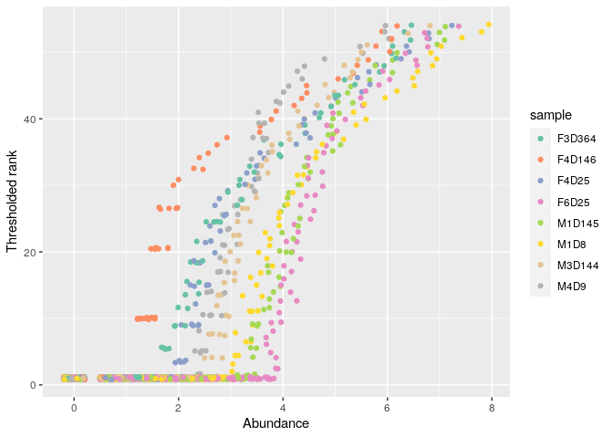

```r
colnames(abund_df) <- c("sample", "seq", "abund", "rank")

sample_ix <- sample(1:nrow(abund_df), 8)
ggplot(abund_df %>%
         filter(sample %in% abund_df$sample[sample_ix])) +
  geom_point(aes(x = abund, y = rank, col = sample),
             position = position_jitter(width = 0.2), size = 1.5) +
  labs(x = "Abundance", y = "Thresholded rank") +
  scale_color_brewer(palette = "Set2")
```

Cette transformation est illustrée dans la figure 14.

L’association entre l’abondance et le rang, pour quelques échantillons choisis au hasard. Les chiffres de l’axe des y sont ceux fournis à l’ACP.

Nous pouvons maintenant effectuer l’ACP et étudier le biplot résultant, donné dans la figure ci-dessous. Pour produire une annotation pour cette figure, nous avons utilisé le bloc suivant.

```r
library(ade4)
```

```r
ranks_pca <- dudi.pca(abund_ranks, scannf = F, nf = 3)
row_scores <- data.frame(li = ranks_pca$li,
                         SampleID = rownames(abund_ranks))
col_scores <- data.frame(co = ranks_pca$co,
                         seq = colnames(abund_ranks))
tax <- tax_table(ps) %>%
  data.frame(stringsAsFactors = FALSE)
tax$seq <- rownames(tax)
main_orders <- c("Clostridiales", "Bacteroidales", "Lactobacillales",
                 "Coriobacteriales")
tax$Order[!(tax$Order %in% main_orders)] <- "Other"
tax$Order <- factor(tax$Order, levels = c(main_orders, "Other"))
tax$otu_id <- seq_len(ncol(otu_table(ps)))
row_scores <- row_scores %>%
  left_join(sample_data(pslog))
col_scores <- col_scores %>%
  left_join(tax)
```

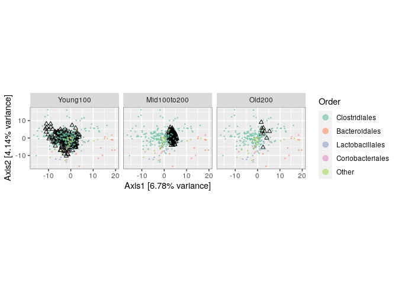

```r
evals_prop <- 100 * (ranks_pca$eig / sum(ranks_pca$eig))
ggplot() +
  geom_point(data = row_scores, aes(x = li.Axis1, y = li.Axis2), shape = 2) +
  geom_point(data = col_scores, aes(x = 25 * co.Comp1, y = 25 * co.Comp2, col = Order),
             size = .3, alpha = 0.6) +
  scale_color_brewer(palette = "Set2") +
  facet_grid(~ age_binned) +
  guides(col = guide_legend(override.aes = list(size = 3))) +
  labs(x = sprintf("Axis1 [%s%% variance]", round(evals_prop[1], 2)),
       y = sprintf("Axis2 [%s%% variance]", round(evals_prop[2], 2))) +
  coord_fixed(sqrt(ranks_pca$eig[2] / ranks_pca$eig[1])) +
  theme(panel.border = element_rect(color = "#787878", fill = alpha("white", 0)))
```

Les résultats sont similaires aux analyses PCoA calculées sans appliquer de transformation de rang tronqué, ce qui renforce notre confiance dans l’analyse des données originales.

### Correspondance canonique

L’analyse des correspondances canonique (CCpnA) est une approche de l’ordination d’un tableau d’espèces par échantillon qui incorpore des informations supplémentaires sur les échantillons. Comme précédemment, le but de la création de biplots est de déterminer quels types de communautés bactériennes sont les plus importants dans les différents types d’échantillons de souris. Il peut être plus facile d’interpréter ces biplots lorsque l’ordre entre les échantillons reflète les caractéristiques de l’échantillon - les variations d’âge ou de statut de la litière dans les données sur les souris, par exemple - et ceci est au cœur de la conception de CCpnA.

La fonction nous permet de créer des biplots où les positions des échantillons sont déterminées par la similarité des signatures d’espèces et des caractéristiques environnementales ; en revanche, l’analyse en composantes principales ou l’analyse des correspondances ne s’intéressent qu’aux signatures d’espèces. Plus formellement, elle garantit que les directions CCpnA résultantes se situent dans l’étendue des variables environnementales ; des traitements approfondis sont disponibles dans (Braak 1985 ; Greenacre 2007).

Comme la PCoA et la DPCoA, cette méthode peut être exécutée à l’aide de la fonction ordinate du package phyloseq. Afin d’utiliser des données d’échantillon supplémentaires, il est nécessaire de fournir un argument supplémentaire, spécifiant quelles caractéristiques doivent être prises en compte - sinon, la méthode utilise par défaut toutes les mesures lors de la production de l’ordination.

```r
ps_ccpna <- ordinate(pslog, "CCA", formula = pslog ~ age_binned + family_relationship)
```

Pour accéder aux positions pour le biplot, nous pouvons utiliser la fonction ordinate dans phyloseq. De plus, pour faciliter l’annotation des figures, nous joignons également les scores des sites avec les données environnementales dans le slot. Sur les 23 ordres taxonomiques totaux, nous n’annotons explicitement que les quatre plus abondants - cela rend le biplot plus facile à lire.

```r
library(ggrepel)
ps_scores <- vegan::scores(ps_ccpna)
sites <- data.frame(ps_scores$sites)
sites$SampleID <- rownames(sites)
sites <- sites %>%
  left_join(sample_data(ps))
species <- data.frame(ps_scores$species)
species$otu_id <- seq_along(colnames(otu_table(ps)))
species <- species %>%
  left_join(tax)
```

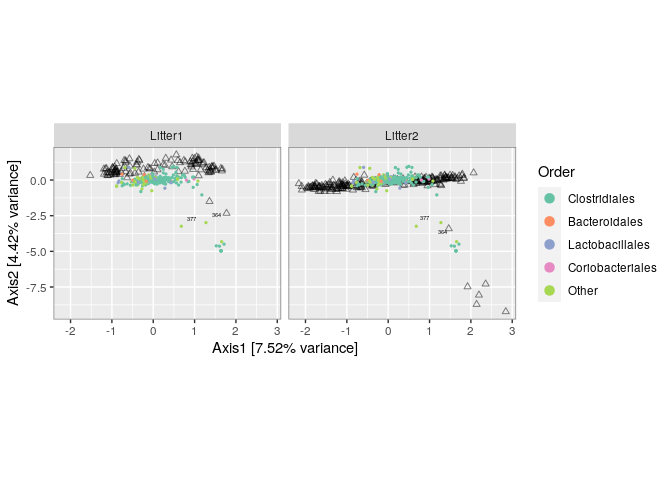

```r
evals_prop <- 100 * ps_ccpna$CCA$eig[1:2] / sum(ps_ccpna$CA$eig)
ggplot() +
  geom_point(data = sites, aes(x = CCA1, y = CCA2), shape = 2, alpha = 0.5) +
  geom_point(data = species, aes(x = CCA1, y = CCA2, col = Order), size = 0.5) +
  geom_text_repel(data = species %>% filter(CCA2 < -2),
                    aes(x = CCA1, y = CCA2, label = otu_id),
            size = 1.5, segment.size = 0.1) +
  facet_grid(. ~ family_relationship) +
  guides(col = guide_legend(override.aes = list(size = 3))) +
  labs(x = sprintf("Axis1 [%s%% variance]", round(evals_prop[1], 2)),
        y = sprintf("Axis2 [%s%% variance]", round(evals_prop[2], 2))) +
  scale_color_brewer(palette = "Set2") +
  coord_fixed(sqrt(ps_ccpna$CCA$eig[2] / ps_ccpna$CCA$eig[1])*0.45   ) +
  theme(panel.border = element_rect(color = "#787878", fill = alpha("white", 0)))
```